# Midterm Practice

Sarah Roffo

10/12/2017

## Lab 1

```r
library(MASS)
library(moments)
df <- Cars93
```

### Question 1 data(Cars93) in the MASS package contains data from 93 cars on sale in 1993.

### Question 1a: Find the cheapest priced car in each Type. Find out the manufacturer and model:

```r
price <- df[df$Type == "Compact", "Price"]
min(price)
```

```
## [1] 11.1
```

```r
df[df$Type == "Compact" & df$Price == 11.1, c("Manufacturer", "Model")]
```

```
##    Manufacturer   Model
## 74      Pontiac Sunbird
```

```r
price <- df[df$Type == "Large", "Price"]
min(price)
```

```
## [1] 18.4
```

```r
df[df$Type == "Large" & df$Price == 18.4, c("Manufacturer", "Model")]
```

```
##    Manufacturer    Model
## 20     Chrylser Concorde
```

```r
price <- df[df$Type == "Midsize", "Price"]
min(price)
```

```
## [1] 13.9
```

```r
df[df$Type == "Midsize" & df$Price == 13.9, c("Manufacturer", "Model")]
```

```
##    Manufacturer  Model
## 47      Hyundai Sonata
```

```r
price <- df[df$Type == "Small", "Price"]
min(price)
```

```
## [1] 7.4
```

```r
df[df$Type == "Small" & df$Price == 7.4, c("Manufacturer", "Model")]
```

```
##    Manufacturer   Model
## 31         Ford Festiva
```

```r
price <- df[df$Type == "Sporty", "Price"]
min(price)
```

```
## [1] 10
```

```r
df[df$Type == "Sporty" & df$Price == 10.0, c("Manufacturer", "Model")]
```

```
##    Manufacturer  Model
## 46      Hyundai Scoupe
```

```r
price <- df[df$Type == "Van", "Price"]
min(price)
```

```
## [1] 16.3
```

```r
df[df$Type == "Van" & df$Price == 16.3, c("Manufacturer", "Model")]
```

```
##    Manufacturer      Model
## 16    Chevrolet Lumina_APV
```

### Question 1b: Find the car with the greatest fuel efficiency (MPG.highway) in each type. Give the Manufacturer and Model:

```r
mpg <- df[df$Type == "Compact", "MPG.highway"]
max(mpg)
```

```
## [1] 36
```

```r
df[df$Type == "Compact" & df$MPG.highway == 36, c("Manufacturer", "Model")]
```

```
##    Manufacturer    Model
## 12    Chevrolet Cavalier
```

```r
mpg <- df[df$Type == "Large", "MPG.highway"]
max(mpg)
```

```
## [1] 28
```

```r
df[df$Type == "Large" & df$MPG.highway == 28, c("Manufacturer", "Model")]
```

```
##    Manufacturer        Model
## 7         Buick      LeSabre
## 20     Chrylser     Concorde
## 30        Eagle       Vision
## 71   Oldsmobile Eighty-Eight
## 77      Pontiac   Bonneville
```

```r
mpg<- df[df$Type == "Midsize", "MPG.highway"]
max(mpg)
```

```
## [1] 31
```

```r
df[df$Type == "Midsize" & df$MPG.highway == 31, c("Manufacturer", "Model")]
```

```
##    Manufacturer         Model
## 6         Buick       Century
## 69   Oldsmobile Cutlass_Ciera
```

```r
mpg <- df[df$Type == "Small", "MPG.highway"]
max(mpg)
```

```
## [1] 50
```

```r
df[df$Type == "Small" & df$MPG.highway == 50, c("Manufacturer", "Model")]
```

```
##    Manufacturer Model
## 39          Geo Metro
```

```r
mpg <- df[df$Type == "Sporty", "MPG.highway"]
max(mpg)
```

```
## [1] 36
```

```r
df[df$Type == "Sporty" & df$MPG.highway == 36, c("Manufacturer", "Model")]
```

```
##    Manufacturer Model
## 40          Geo Storm
```

```r
mpg <- df[df$Type == "Van", "MPG.highway"]
max(mpg)
```

```
## [1] 24
```

```r
df[df$Type == "Van" & df$MPG.highway == 24, c("Manufacturer", "Model")]
```

```
##    Manufacturer Model
## 56        Mazda   MPV
```

### Question 2

### Question 2a: Compute the mean horsepower for each type:

```r
##compact
hp_c <- df[df$Type == "Compact", "Horsepower"]
mean_hp_c <- mean(hp_c)

##large
hp_l <- df[df$Type == "Large", "Horsepower"]
mean_hp_l <- mean(hp_l)

##midsize
hp_m <- df[df$Type == "Midsize", "Horsepower"]
mean_hp_m <- mean(hp_m)

##small
hp_sm <- df[df$Type == "Small", "Horsepower"]
mean_hp_sm <- mean(hp_sm)

##sporty
hp_sp <- df[df$Type == "Sporty", "Horsepower"]
mean_hp_sp <- mean(hp_sp)

##van
hp_v <- df[df$Type == "Van", "Horsepower"]
mean_hp_v <- mean(hp_v)
```

### Question 2b: Compute the difference between each car’s horsepower and mean for its Type. Calculate the Skewness and Kurtosis of the differences in Horsepower for each type:

```r
##compact
compact <- df[df$Type == "Compact", c("Manufacturer", "Model", "Horsepower")]
Diff <- hp_c - mean_hp_c
cbind(compact, Diff)
```

```
##     Manufacturer    Model Horsepower Diff
## 3           Audi       90        172   41
## 12     Chevrolet Cavalier        110  -21
## 13     Chevrolet  Corsica        110  -21
## 21      Chrysler  LeBaron        141   10
## 25         Dodge   Spirit        100  -31
## 33          Ford    Tempo         96  -35
## 43         Honda   Accord        140    9
## 55         Mazda      626        164   33
## 58 Mercedes-Benz     190E        130   -1
## 65        Nissan   Altima        150   19
## 68    Oldsmobile  Achieva        155   24
## 74       Pontiac  Sunbird        110  -21
## 78          Saab      900        140    9
## 82        Subaru   Legacy        130   -1
## 90    Volkswagen   Passat        134    3
## 92         Volvo      240        114  -17
```

```r
skewness(Diff)
```

```
## [1] 0.1321467
```

```r
kurtosis(Diff)
```

```
## [1] 2.006859
```

```r
##Large
Large <- df[df$Type == "Large", c("Manufacturer", "Model", "Horsepower")]
Diff <- hp_l - mean_hp_l
cbind(Large, Diff)
```

```
##    Manufacturer          Model Horsepower        Diff
## 7         Buick        LeSabre        170  -9.4545455
## 8         Buick     Roadmaster        180   0.5454545
## 10     Cadillac        DeVille        200  20.5454545
## 18    Chevrolet        Caprice        170  -9.4545455
## 20     Chrylser       Concorde        153 -26.4545455
## 22     Chrysler       Imperial        147 -32.4545455
## 30        Eagle         Vision        214  34.5454545
## 38         Ford Crown_Victoria        190  10.5454545
## 52      Lincoln       Town_Car        210  30.5454545
## 71   Oldsmobile   Eighty-Eight        170  -9.4545455
## 77      Pontiac     Bonneville        170  -9.4545455
```

```r
skewness(Diff)
```

```
## [1] 0.2364544
```

```r
kurtosis(Diff)
```

```
## [1] 1.989505
```

```r
##Midsize
Midsize <- df[df$Type == "Midsize", c("Manufacturer", "Model", "Horsepower")]
Diff <- hp_m - mean_hp_m
cbind(Midsize, Diff)
```

```
##     Manufacturer         Model Horsepower       Diff
## 2          Acura        Legend        200  26.909091
## 4           Audi           100        172  -1.090909
## 5            BMW          535i        208  34.909091
## 6          Buick       Century        110 -63.090909
## 9          Buick       Riviera        170  -3.090909
## 11      Cadillac       Seville        295 121.909091
## 15     Chevrolet        Lumina        110 -63.090909
## 27         Dodge       Dynasty        100 -73.090909
## 37          Ford        Taurus        140 -33.090909
## 47       Hyundai        Sonata        128 -45.090909
## 48      Infiniti           Q45        278 104.909091
## 49         Lexus         ES300        185  11.909091
## 50         Lexus         SC300        225  51.909091
## 51       Lincoln   Continental        160 -13.090909
## 59 Mercedes-Benz          300E        217  43.909091
## 61       Mercury        Cougar        140 -33.090909
## 63    Mitsubishi      Diamante        202  28.909091
## 67        Nissan        Maxima        160 -13.090909
## 69    Oldsmobile Cutlass_Ciera        110 -63.090909
## 76       Pontiac    Grand_Prix        200  26.909091
## 86        Toyota         Camry        130 -43.090909
## 93         Volvo           850        168  -5.090909
```

```r
skewness(Diff)
```

```
## [1] 0.6419202
```

```r
kurtosis(Diff)
```

```
## [1] 2.905094
```

```r
##Small
Small <- df[df$Type == "Small", c("Manufacturer", "Model", "Horsepower")]
Diff <- hp_sm - mean_hp_sm
cbind(Small, Diff)
```

```
##    Manufacturer   Model Horsepower Diff
## 1         Acura Integra        140   49
## 23        Dodge    Colt         92    1
## 24        Dodge  Shadow         93    2
## 29        Eagle  Summit         92    1
## 31         Ford Festiva         63  -28
## 32         Ford  Escort        127   36
## 39          Geo   Metro         55  -36
## 42        Honda   Civic        102   11
## 44      Hyundai   Excel         81  -10
## 45      Hyundai Elantra        124   33
## 53        Mazda     323         82   -9
## 54        Mazda Protege        103   12
## 62   Mitsubishi  Mirage         92    1
## 64       Nissan  Sentra        110   19
## 73      Pontiac  LeMans         74  -17
## 79       Saturn      SL         85   -6
## 80       Subaru   Justy         73  -18
## 81       Subaru  Loyale         90   -1
## 83       Suzuki   Swift         70  -21
## 84       Toyota  Tercel         82   -9
## 88   Volkswagen     Fox         81  -10
```

```r
skewness(Diff)
```

```
## [1] 0.637789
```

```r
kurtosis(Diff)
```

```
## [1] 3.015564
```

```r
##Sporty
Sporty <- df[df$Type == "Sporty", c("Manufacturer", "Model", "Horsepower")]
Diff <- hp_sp - mean_hp_sp
cbind(Sporty, Diff)
```

```
##    Manufacturer    Model Horsepower        Diff
## 14    Chevrolet   Camaro        160  -0.1428571
## 19    Chevrolet Corvette        300 139.8571429
## 28        Dodge  Stealth        300 139.8571429
## 34         Ford  Mustang        105 -55.1428571
## 35         Ford    Probe        115 -45.1428571
## 40          Geo    Storm         90 -70.1428571
## 41        Honda  Prelude        160  -0.1428571
## 46      Hyundai   Scoupe         92 -68.1428571
## 57        Mazda     RX-7        255  94.8571429
## 60      Mercury    Capri        100 -60.1428571
## 72     Plymouth    Laser         92 -68.1428571
## 75      Pontiac Firebird        160  -0.1428571
## 85       Toyota   Celica        135 -25.1428571
## 91   Volkswagen  Corrado        178  17.8571429
```

```r
skewness(Diff)
```

```
## [1] 0.9416759
```

```r
kurtosis(Diff)
```

```
## [1] 2.541832
```

```r
##Van
Van <- df[df$Type == "Van", c("Manufacturer", "Model", "Horsepower")]
Diff <- hp_v - mean_hp_v
cbind(Van, Diff)
```

```
##    Manufacturer      Model Horsepower       Diff
## 16    Chevrolet Lumina_APV        170  20.555556
## 17    Chevrolet      Astro        165  15.555556
## 26        Dodge    Caravan        142  -7.444444
## 36         Ford   Aerostar        145  -4.444444
## 56        Mazda        MPV        155   5.555556
## 66       Nissan      Quest        151   1.555556
## 70   Oldsmobile Silhouette        170  20.555556
## 87       Toyota     Previa        138 -11.444444
## 89   Volkswagen    Eurovan        109 -40.444444
```

```r
skewness(Diff)
```

```
## [1] -0.8717084
```

```r
kurtosis(Diff)
```

```
## [1] 3.192784
```

### Question 3: Make two new dataframes for USA and non-USA cars:

```r
USA.df <- df[df$Origin == "USA",]
non_USA.df <- df[df$Origin == "non-USA",]
```

### Question 4: Save the USA datafram as a csv file. Read it in and check that all factors are set as factors

```r
write.csv(USA.df, file = "USA.df.csv")
tbl <- read.csv("USA.df.csv")
str(tbl)
```

```
## 'data.frame':    48 obs. of  28 variables:
##  $ X                 : int  6 7 8 9 10 11 12 13 14 15 ...
##  $ Manufacturer      : Factor w/ 14 levels "Buick","Cadillac",..: 1 1 1 1 2 2 3 3 3 3 ...
##  $ Model             : Factor w/ 48 levels "Achieva","Aerostar",..: 10 30 36 35 19 37 9 14 5 31 ...
##  $ Type              : Factor w/ 6 levels "Compact","Large",..: 3 2 2 3 2 3 1 1 5 3 ...
##  $ Min.Price         : num  14.2 19.9 22.6 26.3 33 37.5 8.5 11.4 13.4 13.4 ...
##  $ Price             : num  15.7 20.8 23.7 26.3 34.7 40.1 13.4 11.4 15.1 15.9 ...
##  $ Max.Price         : num  17.3 21.7 24.9 26.3 36.3 42.7 18.3 11.4 16.8 18.4 ...
##  $ MPG.city          : int  22 19 16 19 16 16 25 25 19 21 ...
##  $ MPG.highway       : int  31 28 25 27 25 25 36 34 28 29 ...
##  $ AirBags           : Factor w/ 3 levels "Driver & Passenger",..: 2 2 2 2 2 1 3 2 1 3 ...
##  $ DriveTrain        : Factor w/ 3 levels "4WD","Front",..: 2 2 3 2 2 2 2 2 3 2 ...
##  $ Cylinders         : int  4 6 6 6 8 8 4 4 6 4 ...
##  $ EngineSize        : num  2.2 3.8 5.7 3.8 4.9 4.6 2.2 2.2 3.4 2.2 ...
##  $ Horsepower        : int  110 170 180 170 200 295 110 110 160 110 ...
##  $ RPM               : int  5200 4800 4000 4800 4100 6000 5200 5200 4600 5200 ...
##  $ Rev.per.mile      : int  2565 1570 1320 1690 1510 1985 2380 2665 1805 2595 ...
##  $ Man.trans.avail   : Factor w/ 2 levels "No","Yes": 1 1 1 1 1 1 2 2 2 1 ...
##  $ Fuel.tank.capacity: num  16.4 18 23 18.8 18 20 15.2 15.6 15.5 16.5 ...
##  $ Passengers        : int  6 6 6 5 6 5 5 5 4 6 ...
##  $ Length            : int  189 200 216 198 206 204 182 184 193 198 ...
##  $ Wheelbase         : int  105 111 116 108 114 111 101 103 101 108 ...
##  $ Width             : int  69 74 78 73 73 74 66 68 74 71 ...
##  $ Turn.circle       : int  41 42 45 41 43 44 38 39 43 40 ...
##  $ Rear.seat.room    : num  28 30.5 30.5 26.5 35 31 25 26 25 28.5 ...
##  $ Luggage.room      : int  16 17 21 14 18 14 13 14 13 16 ...
##  $ Weight            : int  2880 3470 4105 3495 3620 3935 2490 2785 3240 3195 ...
##  $ Origin            : Factor w/ 1 level "USA": 1 1 1 1 1 1 1 1 1 1 ...
##  $ Make              : Factor w/ 48 levels "Buick Century",..: 1 2 4 3 5 6 10 11 8 13 ...
```

## Lab 3

```r
library(MASS)
df <- Cars93
```

### Question 1: Question 1 data(Cars93) in the MASS package contains data from 93 cars on sale in 1993.

### Question 1a: Randomly select 40 cars as the training dataset and the remaining 53 cars as the test dataset:

```r
set.seed(12)
training_dataset <- sample(1:nrow(df), 40, replace = FALSE)
index <- as.numeric(row.names(df))
test_dataset <- index[- training_dataset]
```

### Question 1b: Save both datasets as csv files:

```r
write.csv(training_dataset, file = "Training.Dataset.csv")
write.csv(test_dataset, file = "Test.Dataset.csv")
```

### Question 1c: Find out the number of USA and non-USA cars in the training dataset:

```r
training_df <- df[training_dataset,]
USA <- training_df[training_df$Origin == "USA",]
non_USA <- training_df[training_df$Origin == "non-USA",]
nrow(USA)
```

```
## [1] 19
```

```r
nrow(non_USA)
```

```
## [1] 21
```

### Question 2: Assume that the probabilities of boy and girl births are 0.515 and 0.485 respectively.

### Question 2a:Use the sample() function to simulate 10 births and print out the result. How many boys and girls do you get out if ten births? Then simulate 10,000 births. How many boys and girls do you get out of 10,000 births?

```r
births <- sample(c("Boy", "Girl"), 10, prob = c(0.515, 0.485), replace = TRUE)
table(births)
```

```
## births
##  Boy Girl
##    5    5
```

```r
many_births <- sample(c("Boy", "Girl"), 10000, prob = c(0.515, 0.485), replace = TRUE)
table(many_births)
```

```
## many_births
##  Boy Girl
## 5100 4900
```

### Question 3: Assume that the probabilities of boy and girl births are 0.515 and 0.485 respectively.

### Question 3a: What is the probability of having exactly 3 births out of 10?

```r
dbinom(3, 10, prob = 0.515)
```

```
## [1] 0.1034654
```

```r
pbinom(8, 10, prob = 0.515, lower.tail = FALSE)
```

```
## [1] 0.01367209
```

### Question 3c: Plot the density function of the number of boy births out of ten:

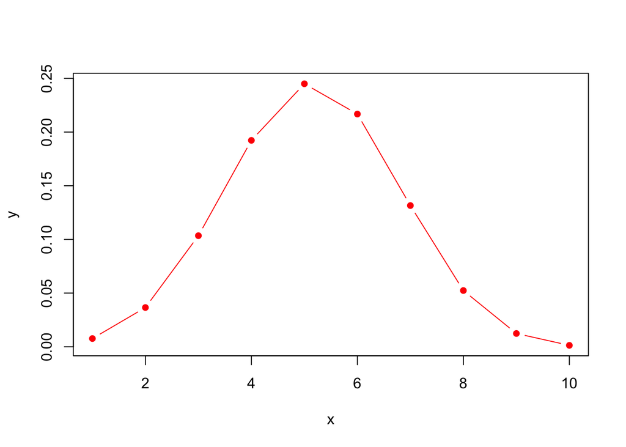

```r
n <- 10
x <- 1:n
y <- dbinom(x, 10, prob = 0.515)
plot(x,y, pch = 16, type = "b", col = "red")
```

### Question 3d: Plot the cumulative probability function of the number of boy births out of ten:

```r
n <- 10
x <- 1:x
```

[figure not shown]

```r
y <- pbinom(x, 10, prob = 0.515)
plot(x,y, pch = 16, type = "b", col = "blue")
```

### Question 4: Cars arrive randomly at a traffic light at a rate of 5 every 10 seconds.

### Question 4a: What’s the probability that exactly 4 cards arrive in the next 10 seconds?

```r
dpois(4, 5)
```

```
## [1] 0.1754674
```

### Question 4b: What’s the probability that more than 5 cars arrive in the next ten seconds?

```r
ppois(5, 5, lower.tail = FALSE)
```

```
## [1] 0.3840393
```

### Question 4c: Plot the density function of 0-20 cars arriving in the next ten seconds:

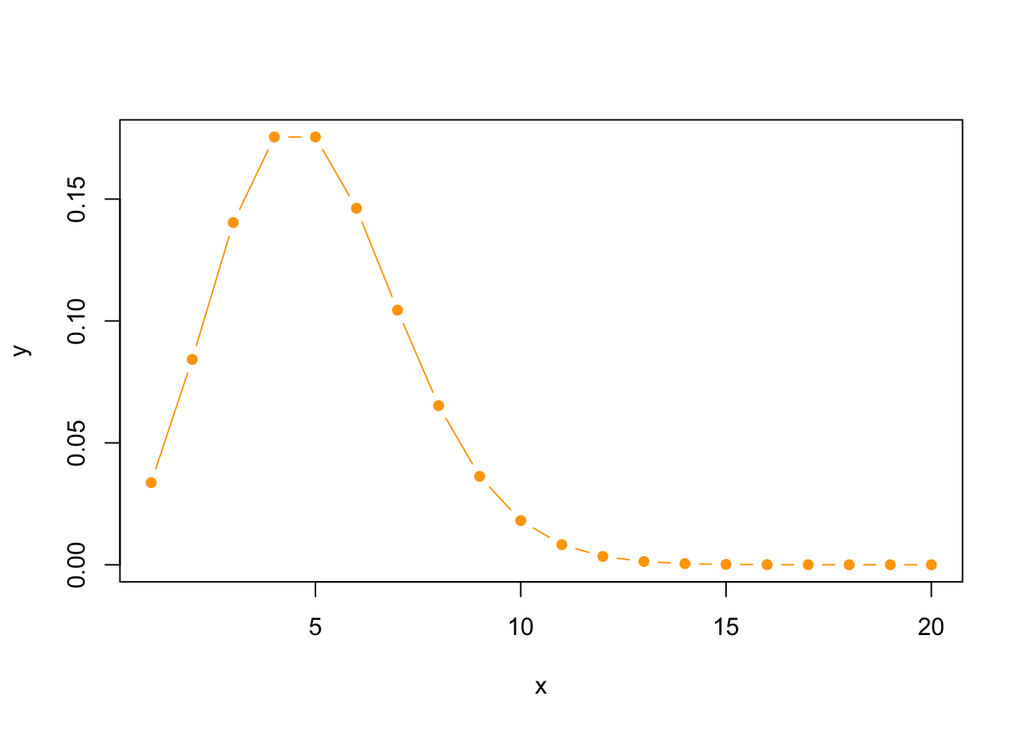

```r
n <- 20
x <- 1:n
y <- dpois(x, 5)
plot(x,y, pch = 16, type = "b", col = "orange")
```

## Lab 4

### Question 1: The number of points scored by a team in a tournament is normally distributed, with mean = 32, sd = 7. What is the probability of:

### Question 1a: What is the probability of a team scoring 20 points or fewer? Plot the density function and shade the area.

```r
pnorm(20, mean = 32, sd = 7)
```

```
## [1] 0.04323813
```

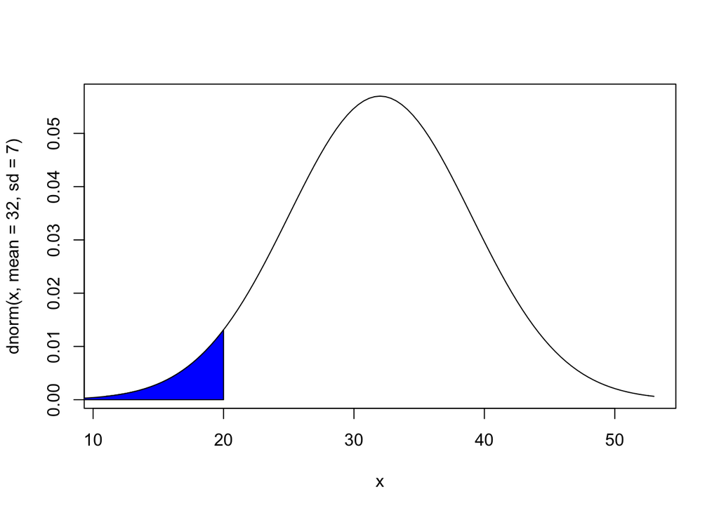

```r
curve(dnorm(x, mean = 32, sd = 7), from = 11, to = 53)
cord.x <- c(0, seq(0, 20, by = 0.01), 20)
cord.y <- c(0, dnorm(seq(0, 20, 0.01), mean = 32, sd = 7), 0)
polygon(cord.x, cord.y, col = "blue")
```

### Question 1b: What is the probability of a team scoring more than 35 points? Plot the density function and shade the area.

```r
pnorm(35, mean = 32, sd = 7, lower.tail = FALSE)
```

```
## [1] 0.3341176
```

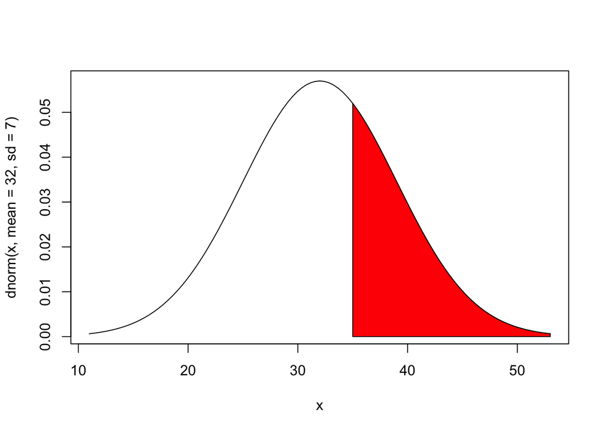

```r
curve(dnorm(x, mean = 32, sd = 7), from = 11, to = 53)
cord.x <- c(35, seq(35, 53, by = 0.01), 53)
cord.y <- c(0, dnorm(seq(35, 53, 0.01), mean = 32, sd = 7), 0)
polygon(cord.x, cord.y, col = "red")
```

### Question 1c: What is the probability of a team scoring between 20 and 40 points? Plot the density function and shade the area.

```r
diff(pnorm(c(20,40), mean = 32, sd = 7))
```

```
## [1] 0.8302129
```

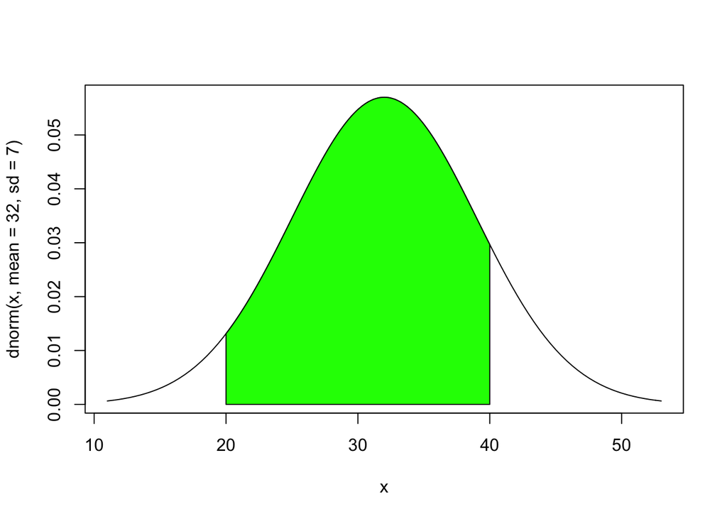

```r
curve(dnorm(x, mean = 32, sd = 7), from = 11, to = 53)
cord.x <- c(20, seq(20, 40, by = 0.01), 40)
cord.y <- c(0, dnorm(seq(20, 40, 0.01), mean = 32, sd = 7), 0)
polygon(cord.x, cord.y, col = "green")
```

### Question 2: The number of comments per post on a social media site is exponentiall distributed, with the average post recieving ten comments. What percentage of posts get:

### Question 2a: Fewer than three comments? Plot the density function and shade the area:

```r
pexp(3, 1/10)
```

```
## [1] 0.2591818
```

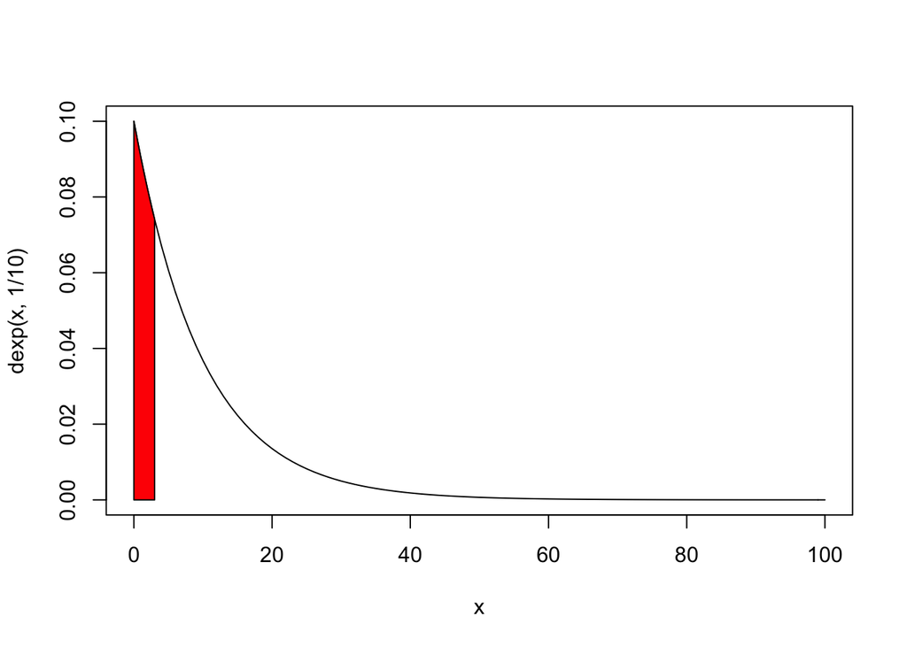

```r
curve(dexp(x, 1/10), from = 0, to = 100)
cord.x <- c(0, seq(0, 3, by = 0.01), 3)
cord.y <- c(0, dexp(seq(0, 3, 0.01), 1/10), 0)
polygon(cord.x, cord.y, col = "red")
```

### Question 2b: More than twenty comments? Plot the density function and shade the area:

```r
pexp(20, 1/10, lower.tail = FALSE)
```

```
## [1] 0.1353353
```

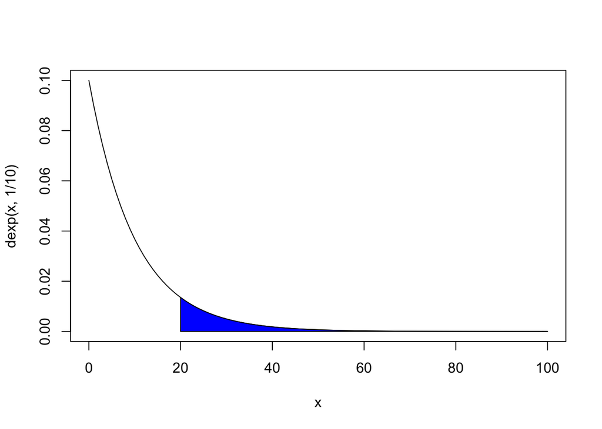

```r
curve(dexp(x, 1/10), from = 0, to = 100)
cord.x <- c(20, seq(20, 100, by = 0.01), 100)
cord.y <- c(0, dexp(seq(20, 100, 0.01), 1/10), 0)
polygon(cord.x, cord.y, col = "blue")
```

### Question 2c: Between five and ten comments? Plot the density function and shade the area:

```r
diff(pexp(c(5, 10), 1/10))
```

```
## [1] 0.2386512
```

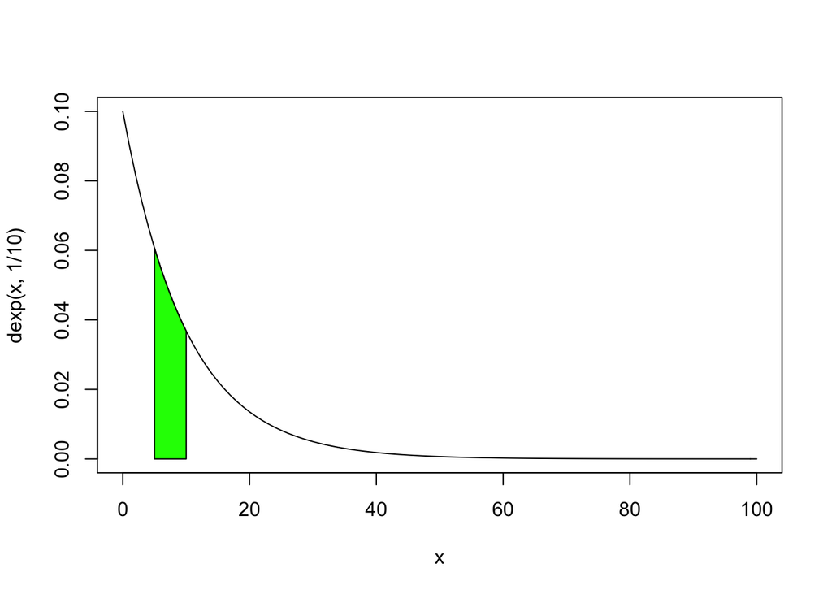

```r
curve(dexp(x, 1/10), from = 0, to = 100)
cord.x <- c(5, seq(5, 10, by = 0.01), 10)
cord.y <- c(0, dexp(seq(5, 10, 0.01), 1/10), 0)
polygon(cord.x, cord.y, col = "green")
```